# Audacity-UCB-Problem

Anusha Ramamurthy

April 15, 2016

Background:

In 1973, the University of California-Berkeley (UC-Berkeley) was sued for sex discrimination. Its admission data showed that men applying to graduate school at UC-Berkley were more likely to be admitted than women.

The graduate schools had just accepted 44% of male applicants but only 35% of female applicants. The difference was so great that it was unlikely to be due to chance.

By looking at the data more closely, you may realize that there is more to the story than meets the eye.

Admit,Gender,Dept,Freq Admitted,Male,A,512 Rejected,Male,A,313 Admitted,Female,A,89 Rejected,Female,A,19 Admitted,Male,B,353 Rejected,Male,B,207 Admitted,Female,B,17 Rejected,Female,B,8 Admitted,Male,C,120 Rejected,Male,C,205 Admitted,Female,C,202 Rejected,Female,C,391 Admitted,Male,D,138 Rejected,Male,D,279 Admitted,Female,D,131 Rejected,Female,D,244 Admitted,Male,E,53 Rejected,Male,E,138 Admitted,Female,E,94 Rejected,Female,E,299 Admitted,Male,F,22 Rejected,Male,F,351 Admitted,Female,F,24 Rejected,Female,F,317

So I take each ratio: Female applicatants accepted by the department to the total number of applicatants applied.

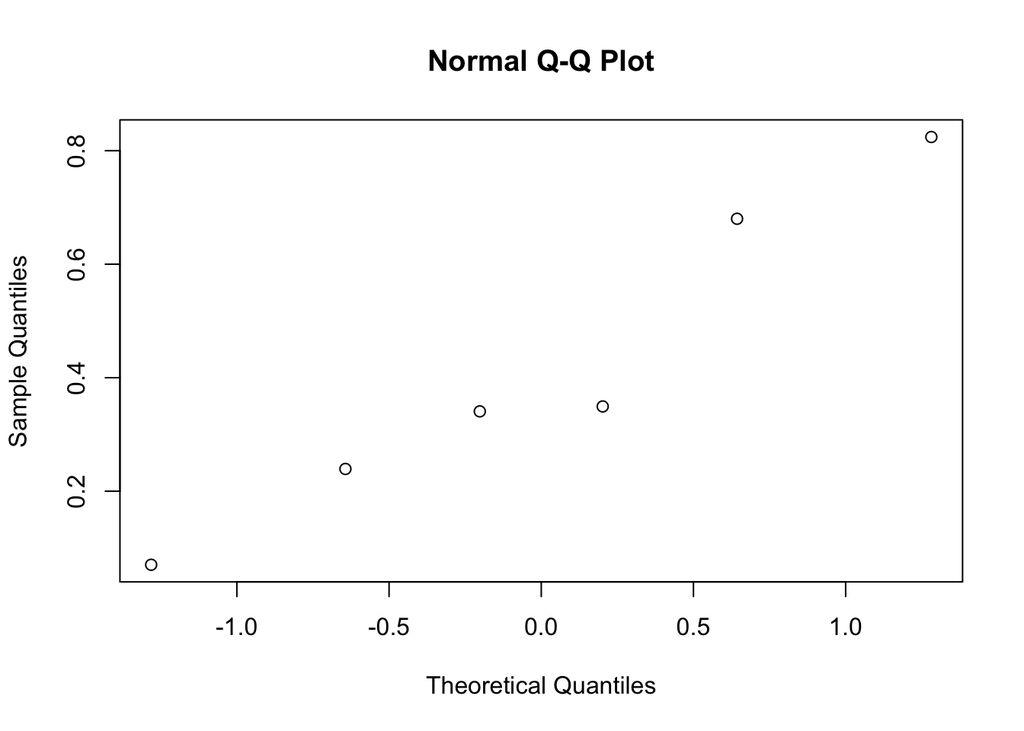

```r
f_admits = c((89/(89+19)),(17/(17+8)),(202/(202+391)),(131/(131+244)),94/(94+299),(24/(24+317)))
m_admits = c((512/(512+313)),(353/(353+207)),(120/(120+205)),(138/(138+279)),(53/(53+138)),(22/(22+35)))
f_mean = mean(f_admits)
m_mean = mean(m_admits)

sd_fadmits= sd(f_admits)
sd_madmits = sd(m_admits)

qqnorm(f_admits)
```

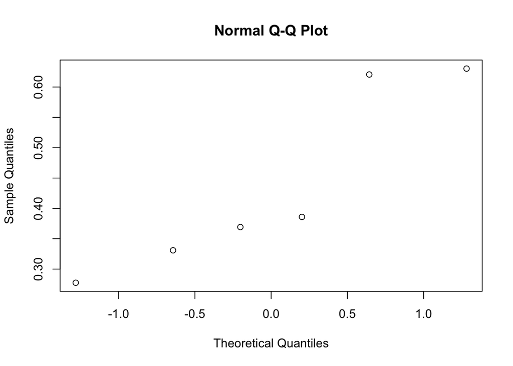

```r
qqnorm(m_admits)
```

The qqplots almost look normal. Lets do Welch’s 2 sample test. My null hypothesis is that there is no difference in the mean of the female admits and the male admits.

```r
t = (f_mean-m_mean)/(sqrt((sd_fadmits^2/6)+(sd_madmits^2/6)))
t
```

```
## [1] -0.1415634
```

```r
#degrees of freedom?

df_fm = (((sd_fadmits^2/6)+(sd_madmits^2/6))^2)/((((sd_fadmits^2/6))/5)+(((sd_madmits^2/6))/5))

t.test(m_admits,f_admits)
```

```
##
##  Welch Two Sample t-test
##
## data:  m_admits and f_admits
## t = 0.14156, df = 7.6718, p-value = 0.8911
## alternative hypothesis: true difference in means is not equal to 0
## 95 percent confidence interval:
##  -0.2850278  0.3220164
## sample estimates:
## mean of x mean of y
## 0.4357635 0.4172692
```

The p-value is quite high. 0.89. Thus I dont reject the hypothesis. So I would say the data is consistent with our hypothesis. The departments are not biased and dont seem to favour male applicatants while giving admissions.